# Model Building 3

Lian Morales

4/26/2021

```r
# pulling the data from the Los Angeles County GitHub
casedata <- read.csv(text = getURL("https://raw.githubusercontent.com/datadesk/california-coronavirus-data/master/latimes-county-totals.csv")) %>%
  filter(county == "Los Angeles") %>%
  mutate(date = date(date), month = month(date)) %>%
  map_df(rev) %>%
  filter(!is.na(new_confirmed_cases) & between(date, date("2020-04-01"),date("2021-03-31")))

# creating the time series
case.ts <- ts(casedata$new_confirmed_cases, start = 1,  frequency = 1)

# averaging dec 25th and 26th
case.ts[269] <- 14711
case.ts[270] <- 14712

## april 1 - sep 30
case.ts.1 <- ts(case.ts[1:183], start = 1, frequency = 1)

# april 1 - jul 14
case.ts.1.1 <- ts(case.ts[1:105], start = 1, frequency = 1)
# jul 15 - sep 30
case.ts.1.2 <- ts(case.ts[106:183], start = 1, frequency = 1)

## oct 1 - mar 31
case.ts.2 <- ts(case.ts[184:365], start = 1, frequency = 1)

# oct 1 - dec 20
case.ts.2.1 <- ts(case.ts[184:264], start = 1, frequency = 1)
# dec 21 - mar 31
case.ts.2.2 <- ts(case.ts[265:365], start = 1, frequency = 1)
```

## October 1 - December 20

## IMA(1,2)X(0,0,1)[7] and IMA(1,2)

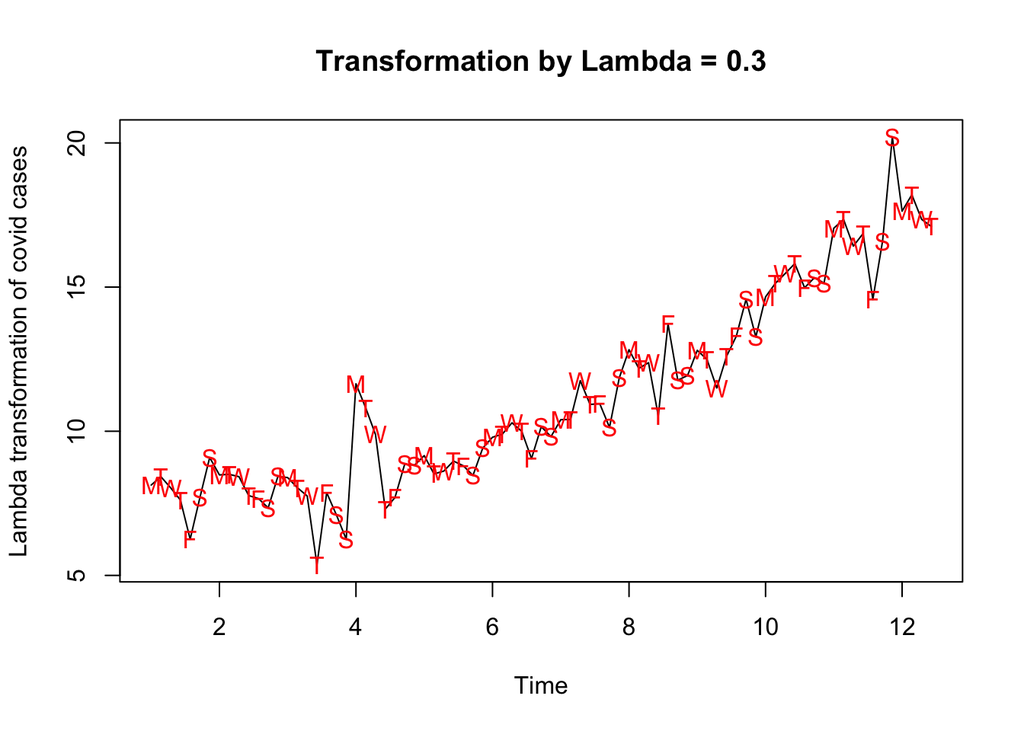

```r
# transform data October 1 - December 20 to lambda + add seasonality
case.ts.2.1_seas.trans <- ts(case.ts.2.1^0.3, frequency = 7)
case.ts.2.1_trans <- ts(case.ts.2.1^0.3)

############ SEASONAL
# plot ts of transformed seasonal data
week. <- season(case.ts.2.1_seas.trans)
plot(case.ts.2.1_seas.trans, ylab = "Lambda transformation of covid cases", xlab = "Time", main = "Transformation by Lambda = 0.3")
points(case.ts.2.1_seas.trans, pch = as.vector(week.), col = "red")
```

```r
par(mfrow = c(2,2))
# acf of transformed data
acf(as.vector(case.ts.2.1_seas.trans), lag.max = 27, main = "ACF of Transformation by Lambda = 0.3")
# pacf of transformed data
pacf(as.vector(case.ts.2.1_seas.trans), lag.max = 27, main = "Transformation by Lambda = 0.3")
# eacf of transformed data
eacf(as.vector(case.ts.2.1_seas.trans)) # seems to show a ARMA(1,1)?
```

```
## AR/MA
##   0 1 2 3 4 5 6 7 8 9 10 11 12 13
## 0 x x x x x x x x x x x  x  x  x
## 1 x o o o o o o o o o o  o  o  o
## 2 x o o o o o o o o o o  o  o  o
## 3 x o o x o o o o o o o  o  o  o
## 4 x x x x o o o o o o o  o  o  o
## 5 o x o x o o o o o o o  o  o  o
## 6 o x o x o o o o o o o  o  o  o
## 7 x o o x o o o o o o o  o  o  o
```

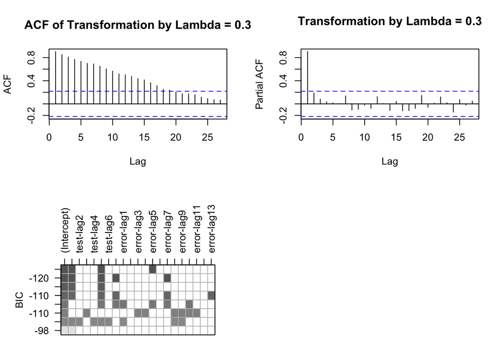

```r
# best subsets ARMA approach
res = armasubsets(y=case.ts.2.1_seas.trans, nar= 7, nma = 13, y.name = "test", ar.method = 'ols')
plot(res) # not sure how to analyze this

############# TRANSFORMATION (no seasonality)
par(mfrow = c(1,1))
```

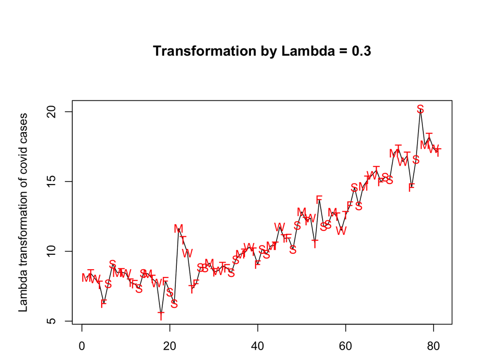

```r
plot(case.ts.2.1_trans, ylab = "Lambda transformation of covid cases", xlab = "Time", main = "Transformation by Lambda = 0.3")
points(case.ts.2.1_trans, pch = as.vector(week.), col = "red")
```

```r
par(mfrow = c(2,2))
# acf of transformed data
acf(as.vector(case.ts.2.1_trans), lag.max = 27, main = "ACF of Transformation by Lambda = 0.3")
# pacf of transformed data
pacf(as.vector(case.ts.2.1_trans), lag.max = 27, main = "Transformation by Lambda = 0.3")
# eacf of transformed data
eacf(as.vector(case.ts.2.1_trans)) # seems to show a ARMA(1,1)?
```

```
## AR/MA
##   0 1 2 3 4 5 6 7 8 9 10 11 12 13
## 0 x x x x x x x x x x x  x  x  x
## 1 x o o o o o o o o o o  o  o  o
## 2 x o o o o o o o o o o  o  o  o
## 3 x o o x o o o o o o o  o  o  o
## 4 x x x x o o o o o o o  o  o  o
## 5 o x o x o o o o o o o  o  o  o
## 6 o x o x o o o o o o o  o  o  o
## 7 x o o x o o o o o o o  o  o  o
```

```r
# best subsets ARMA approach
res = armasubsets(y=case.ts.2.1_trans, nar= 7, nma = 13, y.name = "test", ar.method = 'ols')
plot(res) # not sure how to analyze this

# simulated model prediction
auto.arima(case.ts.2.1_seas.trans)
```

```
## Series: case.ts.2.1_seas.trans
## ARIMA(0,1,2)(0,0,1)[7] with drift
##
## Coefficients:
##           ma1      ma2    sma1   drift
##       -0.5695  -0.2049  0.1970  0.1270
## s.e.   0.1128   0.1093  0.1245  0.0344
##
## sigma^2 estimated as 1.249:  log likelihood=-120.86
## AIC=251.73   AICc=252.54   BIC=263.64
```

```r
auto.arima(case.ts.2.1_trans)
```

```
## Series: case.ts.2.1_trans
## ARIMA(0,1,2) with drift
##
## Coefficients:
##           ma1      ma2   drift
##       -0.5567  -0.1929  0.1271
## s.e.   0.1126   0.1061  0.0326
##
## sigma^2 estimated as 1.274:  log likelihood=-122.03
## AIC=252.06   AICc=252.59   BIC=261.59
```

[figure not shown]

```r
# simualte aimra models for seasonal and transformed data
arima.seas_trans <- arima(case.ts.2.1_seas.trans,
                          order = c(0,1,2),
                          seasonal = list(order = c(0,1,2), period = 7))
arima.trans <- arima(case.ts.2.1_trans, order = c(0,1,2))

# residual tests

# check for correlation of error terms
Box.test(rstandard(arima.seas_trans), type = "Ljung-Box")
```

```
##
##  Box-Ljung test
##
## data:  rstandard(arima.seas_trans)
## X-squared = 0.33756, df = 1, p-value = 0.5612
```

```r
Box.test(rstandard(arima.trans), type = "Ljung-Box")
```

```
##
##  Box-Ljung test
##
## data:  rstandard(arima.trans)
## X-squared = 0.48346, df = 1, p-value = 0.4869
```

```r
# check for independence of error terms
runs(rstandard(arima.seas_trans))
```

```
## $pvalue
## [1] 0.991
##
## $observed.runs
## [1] 42
##
## $expected.runs
## [1] 41.44444
##
## $n1
## [1] 39
##
## $n2
## [1] 42
##
## $k
## [1] 0
```

```r
runs(rstandard(arima.trans))
```

```
## $pvalue
## [1] 0.676
##
## $observed.runs
## [1] 42
##
## $expected.runs
## [1] 39.71605
##
## $n1
## [1] 32
##
## $n2
## [1] 49
##
## $k
## [1] 0
```

```r
# check for normality of error terms
shapiro.test(rstandard(arima.seas_trans))
```

```
##
##  Shapiro-Wilk normality test
##
## data:  rstandard(arima.seas_trans)
## W = 0.93447, p-value = 0.0004514
```

```r
shapiro.test(rstandard(arima.trans))
```

```
##
##  Shapiro-Wilk normality test
##
## data:  rstandard(arima.trans)
## W = 0.93084, p-value = 0.0002935
```

**Ljung-Box**

*seasonal transformed model* For the seasonal transformed data, the residuals from the Ljung-Box test have a high p-value of 0.5612, which indicate that the residuals are uncorrelated.

*transformed model* Similarly, in the transformed data with no seasonality, the p-value is very high, 0.4869, therefore we do not have evidence against the null hypothesis that the error terms are uncorrelated.

**Runs Test**

*seasonal transformed model* For the runs test, we notice that the seasonal transformed model has observed runs of 42 versus expected runs of 41.44. The p-value of this test is large, equalling 0.991, which means we do not have statistically significant evidence against independence of the error terms in the model.

*transformed model* For the transformed model, the model has an observed runs of 42 and expected of 39.7. Similar to the seasonal model, this runs test has a high p-value of 0.676. Although this is not as high as the seasonal model, it still indicated that we do not have statistically significant evidence against independence of the error terms in the model.

**Shapiro Wilks Test**

*seasonal transformed model* For the seasonal model, we notice that the p-value for this test is very small, with 0.0004514, indicating that we do have evidence against the null hypothesis that the data are normal.

*transformed model* Similar to the seasonal model, the transformed data have a p-value of 0.0002935 indicating that we do have evidence against the null hypothesis that the data are normal.

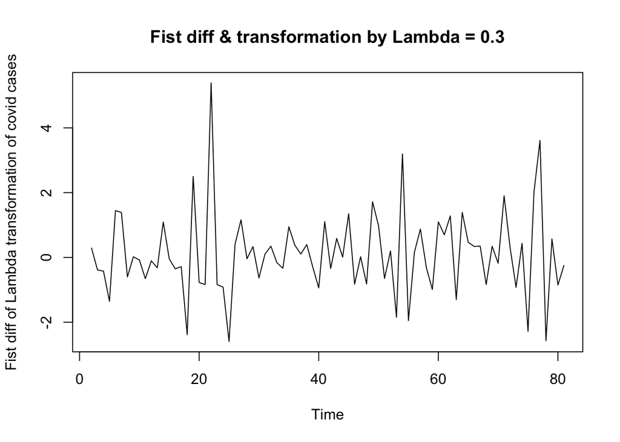

```r
# find the first difference
diff1_case.2.1 <- diff(case.ts.2.1_trans)
# plot of first difference
plot(diff1_case.2.1, ylab = "Fist diff of Lambda transformation of covid cases", xlab = "Time", main = "Fist diff & transformation by Lambda = 0.3")
```

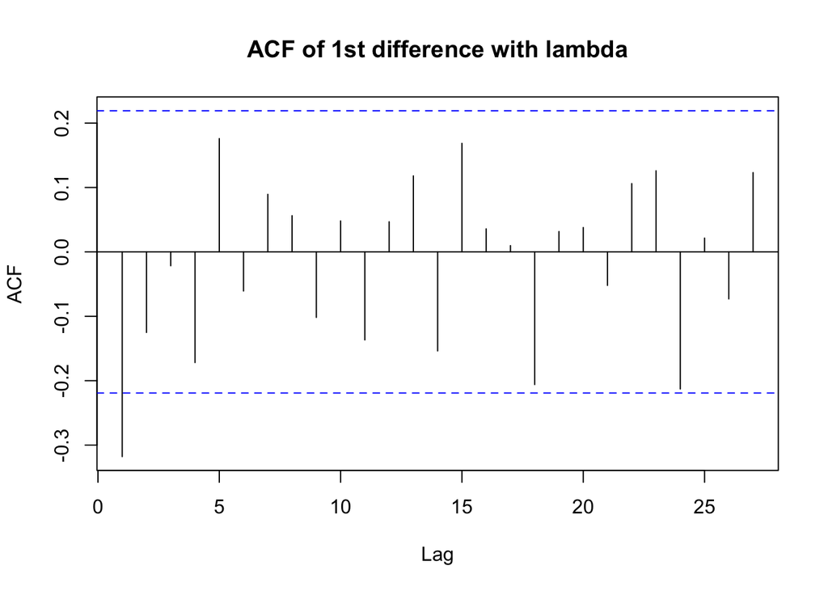

```r
# acf of first difference
acf(as.vector(diff1_case.2.1), lag.max = 27, main = "ACF of 1st difference with lambda")
```

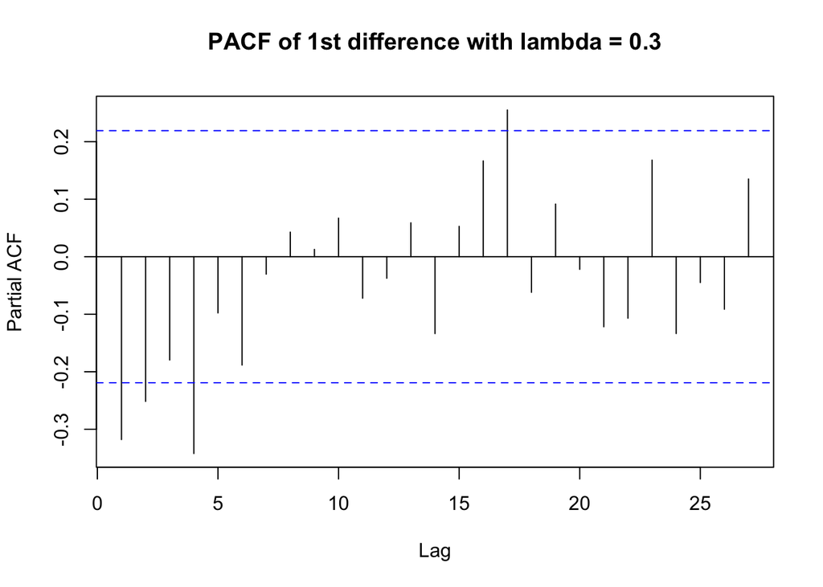

```r
# pacf of first difference
pacf(as.vector(diff1_case.2.1), lag.max = 27, main = "PACF of 1st difference with lambda = 0.3")
```

```r
# eacf of first difference
eacf(as.vector(diff1_case.2.1))
```

```
## AR/MA
##   0 1 2 3 4 5 6 7 8 9 10 11 12 13
## 0 x o o o o o o o o o o  o  o  o
## 1 x o o o o o o o o o o  o  o  o
## 2 x o o o o o o o o o o  o  o  o
## 3 x x x x o o o o o o o  o  o  o
## 4 x x o x o o o o o o o  o  o  o
## 5 x x o x o o o o o o o  o  o  o
## 6 o x o x o o o o o o o  o  o  o
## 7 x x o o o o o o o o o  o  o  o
```

```r
# best subsets ARMA approach for first difference
res = armasubsets(y=diff1_case.2.1, nar= 7, nma = 13, y.name = "test", ar.method = 'ols')
```

```
## Reordering variables and trying again:
```

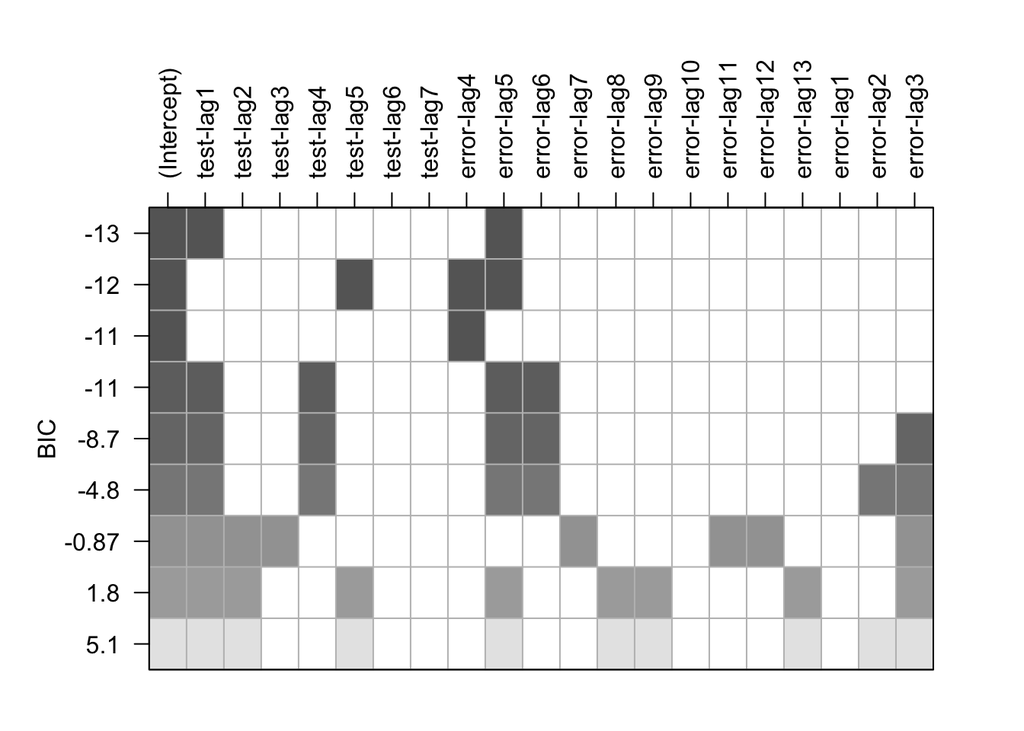

```r
plot(res) # not sure how to analyze this
```

```r
# find the best model for first difference
auto.arima(diff1_case.2.1)
```

```
## Series: diff1_case.2.1
## ARIMA(0,0,2) with non-zero mean
##
## Coefficients:
##           ma1      ma2    mean
##       -0.5567  -0.1929  0.1271
## s.e.   0.1126   0.1061  0.0326
##
## sigma^2 estimated as 1.274:  log likelihood=-122.03
## AIC=252.06   AICc=252.59   BIC=261.59
```